# Predicting Left-Handed Batting Performance

Max Brown, Noah Costa, Aritra Acharjee, Jack Casey

2023-09-13

### Introduction

The MLB enacted several rule changes in the 2022-23 offseason to increase engagement and appeal to a younger audience. Some rule changes, such as introducing the pitch clock and limiting the number of pickoff attempts, were instituted to shorten the length of a game. Still, the most significant rule change in altering overall game strategy was the implementation of infield shifting rules. The new rule restricts defensive alignments so fielding teams must position their infielders on the dirt and two on each side of second base. The primary purpose of eliminating the shift, defined as having at least three infielders on one side of second base, was to increase overall offense to provide a more action-filled product as the MLB batting average reached a 55-year low of .243 in 2022. The analytics teams and coaching staff for MLB organizations were able to deduce tendencies for hitters and optimize defensive alignment to minimize a ball in play, particularly a ground ball, resulting in a base hit.

The 2023 season has provided early indications that the MLB has been successful in increasing offense. According to Baseball Reference, MLB batting average has risen slightly to .248, and runs per game have jumped to 4.58 (as of 8/12/23) compared to an 8-year low of 4.28 in 2022. While each rule change has played a role in increasing the MLB’s product value, we believe eliminating the shift has had the most substantial effect. Teams have historically shifted more often against left-handed hitters compared to right-handed hitters because infield positioning is better optimized against lefties. Shifting against righties still requires a first-baseman to play close to the first base line to cover the base on a potential groundball putout, occupying an area that leaves a much larger gap on the right side of the infield. According to Baseball Savant, teams shifted 52.6% of plate appearances against left-handed hitters in 2021, a much larger percentage than a shift rate of 16.2% against righties in the same year. For this reason, our analysis will focus on identifying left-handed hitters and overall hitting tendencies that suggest greater offensive success in 2023 with defensive restrictions put into place.

### Data Description

Our play-by-play data of the 2022 season is sourced by Baseball Savant where each row is a ball put into play by a left-handed hitter. In gathering data we encountered an issue where Baseball Savant would not allow for tens of thousands of pitches to be pulled into a single csv file. Therefore, our team had to adjust. We set a threshold of at least 50 pitches put into play and pulled data from each month of the season. Therefore, one big limitation within our data is that some players’ full data isn’t included under the circumstance of an injury that prevented 50 plate appearances from being reached in a given calendar month. To adjust for some cases in which some players reached the 50 plate appearance threshold for a given month but did not play a full season, we filtered for players with at least 200 at-bats with the ball put into play. Different filtration of the data is described within each subsection.

Variables of focus are:

- “launch_speed”: The speed of the baseball once contact is made with the bat. (Continuous & Quantitative)
- “launch_angle”: The angle in degrees at which the ball travels once made contact with the bat. (Continuous & Quantitative)
- “bb_type”: The type of hit classified on Trackman dependent on the launch angle. {ground_ball, line_drive, fly_ball, popup}
- “if_alignment”: The positioning of the infield when the ball is hit. “Infield shift” indicates that there are three people on either side of second base, “standard” means that infielders are located in their typical positions, and “strategic” occurs when there are not three people on one side of the base, but infielders are not positioned in their normal spots as well. (Qualitative)
- “player_name”: Listed as last name, first name
- “hc_x”: Horizontal location of the baseball’s landing position. X=125 is a vertical line that runs through the center of home plate, the pitcher’s mound, and second base. A pulled baseball is therefore defined as a baseball with a landing position greater than 125.
- “hc_y”: The vertical location of the baseball’s landing position.

### Predicting Hitter Success Without Defensive Shift Alignments

In this section, we analyzed the 20 left-handed hitters who pulled the ball the most in the 2022 MLB season. Our goal was to see how often they were being shifted and how their at-bats differed when they were shifted versus when they were not shifted. With information on both the frequency of facing a shifted defense and the overall difference in BABIP among these batters, we believe we can make predictions on how these batters will fare in the 2023 season when they are exclusively facing unshifted defenses.

| player_name | prop_shifted | prop_pulled |
| --- | --- | --- |
| Santana, Carlos | 0.972 | 0.765 |
| Raleigh, Cal | 0.952 | 0.683 |
| Calhoun, Kole | 0.937 | 0.663 |
| Odor, Rougned | 0.935 | 0.657 |
| Hicks, Aaron | 0.931 | 0.663 |
| Ramírez, José | 0.931 | 0.681 |
| Bellinger, Cody | 0.917 | 0.662 |
| Kepler, Max | 0.904 | 0.647 |
| Muncy, Max | 0.895 | 0.654 |
| Santander, Anthony | 0.855 | 0.674 |
| Rutschman, Adley | 0.821 | 0.658 |
| Ruiz, Keibert | 0.820 | 0.709 |
| Tellez, Rowdy | 0.785 | 0.658 |
| Heim, Jonah | 0.783 | 0.705 |
| Melendez, MJ | 0.749 | 0.654 |
| Naylor, Josh | 0.749 | 0.672 |
| Marte, Ketel | 0.687 | 0.662 |
| Grisham, Trent | 0.625 | 0.664 |
| Rengifo, Luis | 0.604 | 0.681 |
| Varsho, Daulton | 0.423 | 0.718 |

Key:

prop_shifted - Proportion of total at bats the batter faced a shift

prop_pulled - Proportion of balls put into play that were pulled

Generally, we can see from the graph above that players who pull the ball more often are more likely to face a shifted defense. However, there is a major distinction between some batters such as Cal Raleigh and Luis Rengifo who have almost identical pulled ball percentages but get shifted at vastly different rates (95% of at-bats versus 60% of at-bats). One possible explanation for the difference is performance against a shifted defense. A team is much more likely to shift if a batter is historically worse against a shifted defense than if a batter is able to overcome the shift. To get more context, we looked at the same dataset of 20 players and found their BABIP and the proportion of hits that were pulled.

| player_name | prop_hit | prop_hit_pulled |
| --- | --- | --- |
| Varsho, Daulton | 0.358 | 0.729 |
| Ramírez, José | 0.332 | 0.690 |
| Rutschman, Adley | 0.330 | 0.569 |
| Raleigh, Cal | 0.308 | 0.820 |
| Calhoun, Kole | 0.297 | 0.549 |
| Naylor, Josh | 0.291 | 0.655 |
| Muncy, Max | 0.290 | 0.791 |
| Ruiz, Keibert | 0.290 | 0.710 |
| Kepler, Max | 0.288 | 0.595 |
| Bellinger, Cody | 0.287 | 0.726 |
| Hicks, Aaron | 0.282 | 0.642 |
| Marte, Ketel | 0.280 | 0.685 |
| Grisham, Trent | 0.279 | 0.690 |
| Rengifo, Luis | 0.274 | 0.628 |
| Tellez, Rowdy | 0.274 | 0.659 |
| Odor, Rougned | 0.270 | 0.556 |
| Heim, Jonah | 0.265 | 0.622 |
| Santander, Anthony | 0.250 | 0.694 |
| Melendez, MJ | 0.247 | 0.645 |
| Santana, Carlos | 0.225 | 0.764 |

Key:

prop_hit - Proportion of balls put into play against a shifted defense that were hits

prop_hit_pulled - Proportion of hit balls against a shifted defense that were pulled

While there are several exceptions, we can see that generally speaking, the players who are shifted against the most have a lower BABIP when they are shifted. This is most notable with Carlos Santana and Daulton Varsho, who are at either end of the extremes. Santana has the highest proportion of at-bats where he faces a shifted defense and has the lowest BABIP against the shift. Varsho, on the other hand, has the lowest proportion of at-bats against a shifted defense among the 20 left-handed batters who pull the ball the most while having the highest BABIP against a shifted defense. While extreme cases like these are easier to analyze, there is certainly more information that results in defenses shifting some batters more than others. With this data, we can see the batters’ BABIP, but we do not take into account how good of a hitter they are on average. Comparing the BABIP of an elite hitter with an average or below average player will likely not tell the complete story of how effective it is to shift the batter. To combat this, we also looked at the BABIP of these players against an unshifted defense and took the difference of the two numbers. By doing this, we believe we measure the effectiveness of a shifted defense on the player’s batting performance.

| player_name | prop_hit_ns | prop_hit_pulled_ns | num_obs_ns | prop_hit | prop_hit_pulled | num_obs_shifted | prop_hit_diff |
| --- | --- | --- | --- | --- | --- | --- | --- |
| Santana, Carlos | 0.571 | 1.000 | 7 | 0.225 | 0.764 | 244 | 0.346 |
| Melendez, MJ | 0.440 | 0.622 | 84 | 0.247 | 0.645 | 251 | 0.193 |
| Ramírez, José | 0.429 | 0.833 | 28 | 0.332 | 0.690 | 380 | 0.097 |
| Rutschman, Adley | 0.419 | 0.833 | 43 | 0.330 | 0.569 | 197 | 0.089 |
| Bellinger, Cody | 0.400 | 0.750 | 30 | 0.287 | 0.726 | 331 | 0.113 |
| Raleigh, Cal | 0.400 | 0.500 | 10 | 0.308 | 0.820 | 198 | 0.092 |
| Santander, Anthony | 0.347 | 0.824 | 49 | 0.250 | 0.694 | 288 | 0.097 |
| Naylor, Josh | 0.340 | 0.794 | 100 | 0.291 | 0.655 | 299 | 0.049 |
| Odor, Rougned | 0.333 | 0.857 | 21 | 0.270 | 0.556 | 300 | 0.063 |
| Ruiz, Keibert | 0.319 | 0.667 | 47 | 0.290 | 0.710 | 214 | 0.029 |
| Calhoun, Kole | 0.312 | 1.000 | 16 | 0.297 | 0.549 | 239 | 0.015 |
| Rengifo, Luis | 0.311 | 0.781 | 103 | 0.274 | 0.628 | 157 | 0.037 |
| Marte, Ketel | 0.307 | 0.778 | 88 | 0.280 | 0.685 | 193 | 0.027 |
| Heim, Jonah | 0.298 | 0.929 | 47 | 0.265 | 0.622 | 170 | 0.033 |
| Tellez, Rowdy | 0.295 | 0.615 | 88 | 0.274 | 0.659 | 321 | 0.021 |
| Varsho, Daulton | 0.289 | 0.831 | 225 | 0.358 | 0.729 | 165 | -0.069 |
| Grisham, Trent | 0.248 | 0.677 | 125 | 0.279 | 0.690 | 208 | -0.031 |
| Hicks, Aaron | 0.214 | 0.667 | 14 | 0.282 | 0.642 | 188 | -0.068 |
| Muncy, Max | 0.171 | 0.500 | 35 | 0.290 | 0.791 | 297 | -0.119 |
| Kepler, Max | 0.129 | 1.000 | 31 | 0.288 | 0.595 | 292 | -0.159 |

Key:

prop_hit_ns - Proportion of balls put into play against an unshifted defense that were hits

prop_pulled_ns - Proportion of hit balls against an unshifted defense that were pulled

num_obs_ns - The number of at-bats a player faced an unshifted defense

prop_hit - Proportion of balls put into play against a shifted defense that were hits

prop_pulled - Proportion of hit balls against a shifted defense that were pulled

num_obs_shifted - The number of at-bats a player faced a shifted defense

prop_hit_diff - The difference in prop_hit_ns and prop_hit

In the data shown above, the players are sorted by their BABIP against an unshifted defense. In the right-most column, we can see the difference between a player’s BABIP against an unshifted defense and the player’s BABIP against a shifted defense. Players that have higher values in the prop_hit_diff category hit significantly better against an unshifted defense than against a shifted defense, making them prime candidates for an improved batting season in 2023. While these proportions can generally tell us how a batter fares in shifted vs unshifted situations, it is important to note that the number of observations is low for some categories. For example, Carlos Santana has a remarkably high 0.572 BABIP against an unshifted defense, but he only faced an unshifted defense 7 times in the 2022 MLB season. If we were to continue this project, one element we would likely want to explore is previous years batting statistics as well to give us more observations and provide less variability in our data.

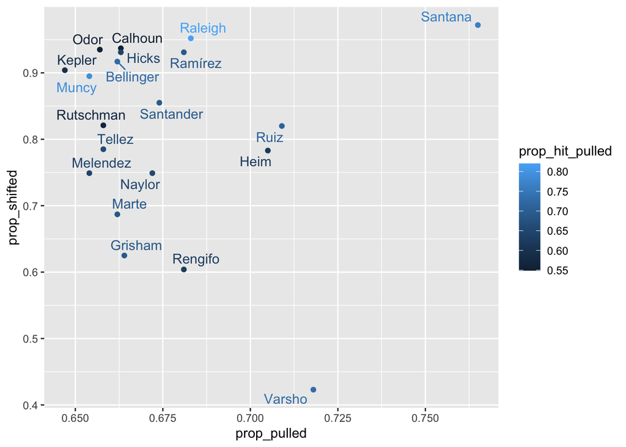

The above graph shows us the relationship between how often a batter pulls the ball and how often they were shifted last season. The color of the data points also provides us with data on how often they pulled the ball when they got a hit against a shifted defense. We generally expect this graph to have a positive relationship because as a batter pulls the ball more often, the more beneficial it would be to align the defense in a shift. The batters who appear towards the top right of the graph (meaning they pull the ball and face a shifted defense often) are the most likely candidates to improve in 2023 because the defense can no longer be shifted. Those who appear in a lighter blue are also more likely to improve because it shows that their hits do not frequently come from adjusting to the shift.

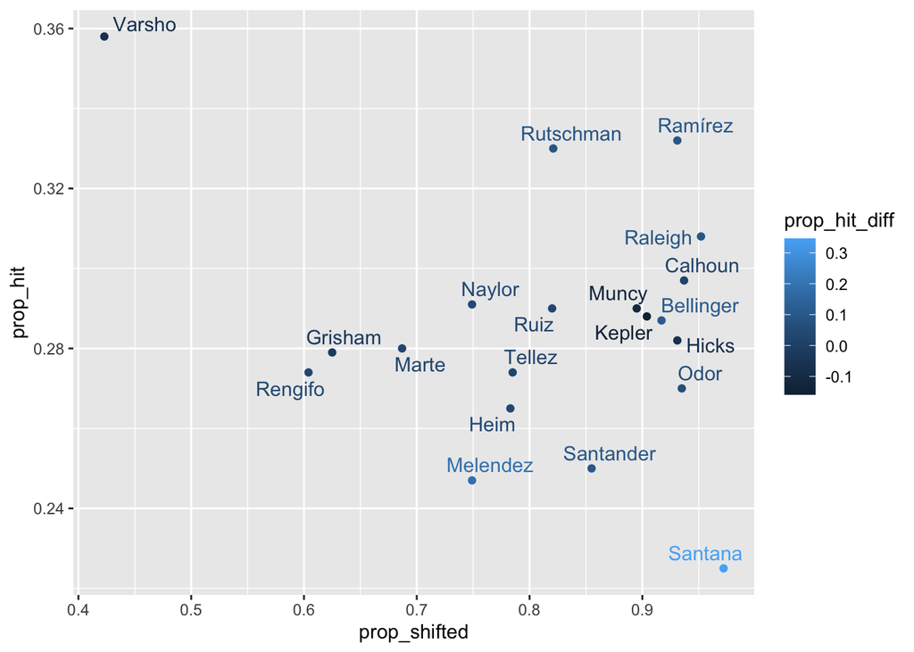

This graph shows the relationship between how often a batter faces a shifted defense and their BABIP against a shifted defense. Batters appearing towards the bottom right of this graph are those that are likely candidates for an improved batting season in 2023 because it indicates that they are constantly being shifted against and have a low BABIP in those situations. Furthermore, the players appearing in the lighter shade of blue bat significantly better against an unshifted defense than a shifted one, which also makes them breakout candidates. On the other hand, players who don’t often face a shifted defense or players who have similar BABIP whatever defense they face will likely not be impacted as significantly by the new rules.

Based on the analysis shown above, we chose Carlos Santana, MJ Melendez, and Cal Raleigh as the 3 players we thought would be affected the most by the new shift rule. Santana and Raleigh are the two batters that were shifted upon the most during the 2022 season, and Santana and Melendez had the greatest increase in BABIP when facing an unshifted defense versus a shifted defense. Looking at these players’ stats so far in 2023 (as of 9/1/23 from baseball-reference.com), each of these 3 batters have a higher batting average than in 2022. Carlos Santana’s batting average is up from .202 in 2022 to .231, MJ Melendez is up from .217 to .231, and Cal Raleigh is up from .284 to .306. These increases support our assumption that players who are shifted upon often and pull the ball frequently will have increased batting stats in 2023. However, it is important to note that there are several other factors that go into these statistics, including age, injuries, and team situation.

Another interesting observation is that Santana and Melendez both have lower on base percentages this year, with Santana dropping from .316 to .312 and Melendez dropping from .313 to .300. If we were to continue this project, an area of interest would be looking into the change in approach of each of these batters and analyzing why their OBS has dropped despite an increase in BA.

### Correlating Shift Alignments with Different Types of Balls In Play (BIP)

After analyzing the hitters that were shifted the most in the 2022 season, we now want to find out who hit the ball in the air most often with a shifted defense. Once again, we are only considering any hitters who at least have 200 Balls In Play (BIP) in our analysis. This gives us a great amount of dataset to work with to draw some conclusions. To find out which hitters hit the ball in the air more often, we have considered the rate of fly-balls, ground-balls, and line-drive rates of left-handed hitters.

| player_name | prop_flyball | prop_line_drive | prop_groundball | prop_shifted | prop_pulled | num_obs |
| --- | --- | --- | --- | --- | --- | --- |
| Raleigh, Cal | 0.490 | 0.207 | 0.303 | 0.952 | 0.683 | 208 |
| Santander, Anthony | 0.481 | 0.199 | 0.320 | 0.855 | 0.674 | 337 |
| Muncy, Max | 0.471 | 0.211 | 0.317 | 0.894 | 0.653 | 331 |
| Escobar, Eduardo | 0.465 | 0.234 | 0.301 | 0.793 | 0.605 | 256 |
| Odor, Rougned | 0.458 | 0.213 | 0.329 | 0.937 | 0.655 | 319 |
| Bellinger, Cody | 0.444 | 0.197 | 0.358 | 0.917 | 0.661 | 360 |
| Schwarber, Kyle | 0.439 | 0.216 | 0.345 | 0.900 | 0.653 | 412 |
| Rizzo, Anthony | 0.439 | 0.213 | 0.348 | 0.816 | 0.647 | 385 |
| Tucker, Kyle | 0.435 | 0.212 | 0.353 | 0.901 | 0.645 | 485 |
| Ramírez, José | 0.429 | 0.235 | 0.336 | 0.931 | 0.681 | 408 |
| Heim, Jonah | 0.429 | 0.198 | 0.373 | 0.783 | 0.705 | 217 |
| Cronenworth, Jake | 0.424 | 0.207 | 0.369 | 0.219 | 0.531 | 493 |
| Ortega, Rafael | 0.422 | 0.225 | 0.353 | 0.398 | 0.610 | 249 |
| Santana, Carlos | 0.422 | 0.191 | 0.386 | 0.972 | 0.765 | 251 |
| Narváez, Omar | 0.413 | 0.223 | 0.364 | 0.529 | 0.524 | 206 |
| Yastrzemski, Mike | 0.411 | 0.239 | 0.351 | 0.796 | 0.644 | 348 |
| Suwinski, Jack | 0.406 | 0.151 | 0.443 | 0.660 | 0.642 | 212 |
| Pederson, Joc | 0.404 | 0.200 | 0.396 | 0.782 | 0.589 | 280 |
| Winker, Jesse | 0.398 | 0.212 | 0.390 | 0.732 | 0.605 | 354 |
| Mullins, Cedric | 0.394 | 0.191 | 0.415 | 0.504 | 0.604 | 482 |

We can see Cal Raleigh tops the chart with the highest fly-ball proportion rate at 49%, meaning almost half of his pulled BIP ends up in a fly-ball. He also faces a shifted defense 95% of his BIP. This could mean that Raleigh tries to get the ball in the air more often in order to get a hit past the shifted infielder. Another player’s statistic that is interesting to see is Jake Cronenworth’s shifted defense rate, which is only 22% of his BIP. Yet he has a relatively high rate of pulling the ball in the air at around 42%. We could infer from this observation that Cronenworth pulls the ball more often in the air without a shifted defense because the right fielder has a better chance at recording the out, or Cronenworth can hit across the baseball field, hence having a shifted defense does not give the fielders an advantage of getting him out.

Now that we have a basic understanding of the players’ fly-ball or line-drive stats against a shifted defense, we wanted to dive deeper into whether there is a correlation between the shift alignment and how often players try to hit the ball in the air. We first created a correlation matrix that includes the values of each of our stats’ proportions from chart 4. Then, we converted the matrix into a correlation plot to give us the correlation values between shift alignments and the fly-ball, line-drive proportions, etc.

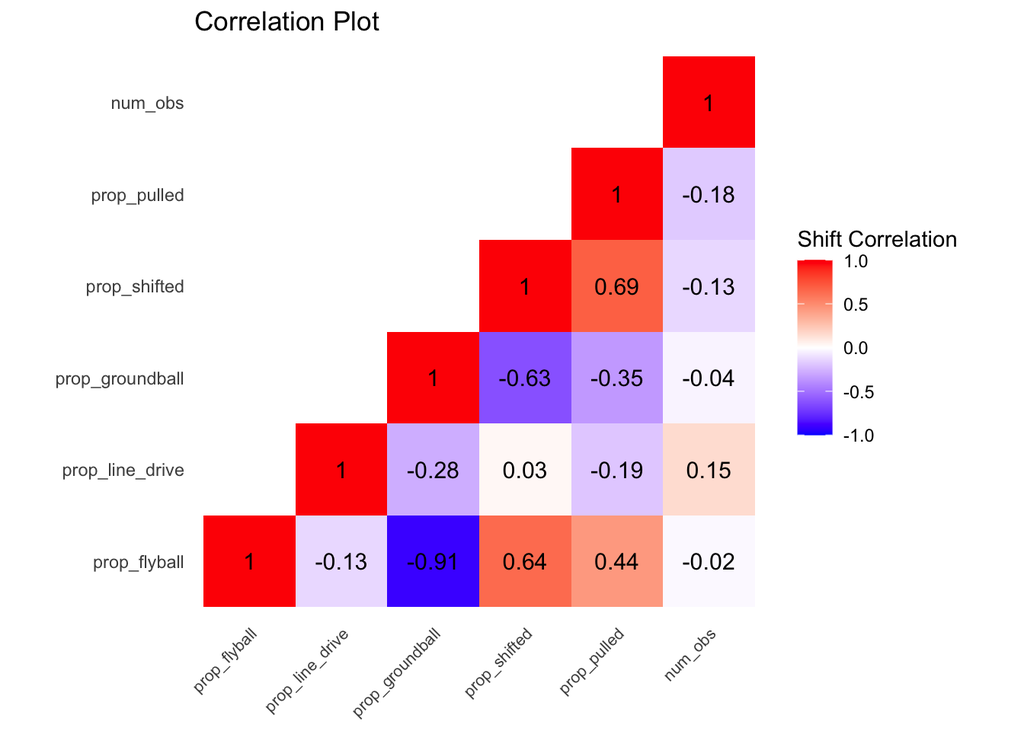

The correlation plot is defined by a combination of red and blue colors. Red defines a positive correlation and blue defines a negative correlation between the variables. We see that there is a very negative correlation (-0.63) between shift and ground-ball proportions. In other words, when the defense is shifted for the left-handed hitter, the hitter tends to put the ball in play less frequently in the ground. However, we see that there is a very positive correlation (0.64) between the shift and fly-ball proportions. This tells us that when defense is shifted, the hitter tries to hit the ball in the air more often. This could be due to the fact that the hitter is trying to pull the ball past the shortstop or second baseman since it gives them a better chance to get a hit. If they played the ball in the ground, then that would be very easily fielded by the shifted defenders which is then turned into a simple groundout towards the first baseman.

For future analysis, an interesting thing to observe would be to compare the correlation between shift alignments and fly-ball/ground-ball proportions statistics of the 2023 MLB season. Since the shift has now been banned, are left-handed hitters still trying to pull the ball in the air more often, or are they trying to get a hit either through ground-balls or line-drives? This information would give us helpful insights as to how left-handed hitters had to change their approach to hitting and whether it gives them more freedom to hit now, or if they are still restricted to launching the ball in the air.

### Assigning Run-Value to New Defensive Strategies

For this section of the analysis, we were attempting to identify patterns in the spray charts of the players who pull the ball the most from the left side. This will allow us to more accurately position fielders to limit hits from opposing teams, with an extra focus on left-handed pull hitters to combat the new shift rules implemented by the MLB.

In order to determine which players pull the ball the most, we sorted the data and filtered down further to only include hitters that put at least 176 balls in play. This number was chosen as it represents the average number of balls put in play by a hitter (70% of ABs) that plays in at least 50% of a team’s games (81 games) and hits enough to qualify (3.1 AB per game), 81*0.7*3.1 = 176. This left us with 120 players to study. Of these 120 players, 97 of them pulled batted balls put in play 55% or more of the time, which is categorized as an extreme-pull hitter by FanGraphs. That is a whopping 81% of left-handed hitters that are considered extreme-pull.

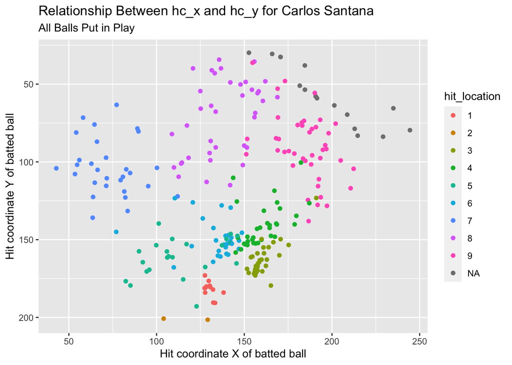

Anthony Rizzo Hit Type Breakdown

| Hit_Type | Pull_Percentage | Pulled_BIP |
| --- | --- | --- |
| Ground Ball | 85.4 | 123 |
| Line Drive | 64.9 | 50 |
| Fly Ball | 47.6 | 79 |

The clear standout of these three values is the amount to which this subset of players pulls ground balls. When facing these hitters, this would be the clear data we target when coaching players and facing these hitters during games. Inducing ground balls from these hitters by pitching low in the zone with negative horizontal movement, such as sinkers, curveballs and changeups, would be the ideal way to pitch to these hitters. From the top ten most pull-heavy lefties, all 10 hit more ground balls than either line drives or fly balls. The two most ground ball heavy hitters, Josh Naylor and Luis Rengifo, both hit ground balls in over 60% of at bats that result in a ball in play. This is where deciding how heavily to shift a player becomes very interesting as Naylor hits the ball on the ground at a staggering rate, however, among the top ten pull heavy hitters, actually pulls ground balls the least at just under 80%. This means that in 50% of Naylor’s at bats that result in a ball in play, he will pull the ball on the ground. But when deciding if it is worth it to shift the left fielder over to shallow right field, we need to do some extra calculations to determine if this is the correct decision over the course of the season.

[figure not shown]

One strategy displayed during spring training this year was shifting the left fielder over to shallow right field to guard against pulled ground balls, while leaving a large gap in left field as hits by lefties are much less common to occur. We will now analyze whether or not this strategy will pay off in the long run of the season. The extra analysis that needs to be done to determine if it is a smart decision to shift pull-heavy lefties is to calculate the expected runs added by leaving left field open. First we found that each team faces an average of 2,062 at-bats by lefty hitters per season, and with about 70% of at-bats resulting in a ball in play, that leaves us with around 1,443 at bats per season with a ball in play from a left handed hitter. Taking the average percentage of fly balls put in play to the opposite field, 13.78%, plus the average percentage of line drives put in play to the opposite field, 6.21%, leaves us with almost exactly 20% of the time that left handed hitters will hit a line drive or fly ball to left field. The next piece we need to determine is the expected runs added during the 20 percent of at bats that result in a ball in left field. Assuming the defense shifts the left fielder to shallow right and there is a gap in left, we are going to presume that this will always result in a double for the hitter. To find the most conservative estimate possible we are going to assume all 1,443 of these at bats are in the most ideal situation for a defense, bases empty with two outs. When looking at FanGraphs RE24, a chart that displays expected runs in all 24 combinations of baserunners and outs, a team goes from 0.095 expected runs with no one on and 2 outs, to 0.305 expected runs with a runner on second and 2 outs. This means that in the situation that we have built, where a hitter hits a line drive or fly ball to an empty left field with two outs and ends up on second with a double, a team expects to score 0.21 more runs. If we take this added expectation and stretch it out over the course of the season, the 1,443 at bats we found earlier multiplied by the average amount that these balls in play end up in left field of 20%, we get a calculation of 0.21 * 1443 * 0.20 which is equal to just over 60. This value of 60 would be the amount of extra runs a team would expect to give up, in the most conservative estimate, if they were to shift the left fielder over to shallow right field every time a left handed hitter came to bat. This would mean that a team is allowing an extra run in about 40% of games played.

FanGraphs RE24 Chart displaying expected runs in all 24 base runner/out combinations

| Runners | 0 Outs | 1 Out | 2 Outs |
| --- | --- | --- | --- |
| Empty | 0.461 | 0.243 | 0.095 |
| 1 _ _ | 0.831 | 0.489 | 0.214 |
| _ 2 _ | 1.068 | 0.644 | 0.305 |
| 1 2 _ | 1.373 | 0.908 | 0.343 |
| _ _ 3 | 1.426 | 0.865 | 0.413 |
| 1 _ 3 | 1.798 | 1.140 | 0.471 |
| _ 2 3 | 1.920 | 1.352 | 0.570 |
| 1 2 3 | 2.282 | 1.520 | 0.736 |

If it were a guarantee that a pitcher could force a batter to hit a ground ball it would be a certainty that teams should shift their left fielder to shallow right field to completely negate any chance of the batter getting a hit. However, there are many more variables to that scenario than there may seem. Pitchers throw certain pitches that induce more ground balls than others, with some even being labeled as “ground-ball pitchers”. And this is the same for batters, some hit more fly-balls than others, especially when looking at pull-heavy lefty’s, increasing average launch angle has been a focus for years to hit the ball over the shift, thereby negating its effectiveness. All of these variables lead to the heavy matchup-dependent focus that we see in the MLB. Pitchers only throw certain pitches in specific spots to lefty hitters, certain alignments for every hitter, pinch hitters for better matchups, all examples of optimizing matchups to put the team in the best position to win.

If I were to continue working on this project, I would do a more in-depth analysis of the exact expected runs changed by shifting the left fielder. Rather than doing a conservative estimate, I would find the percentage of time that each of the scenarios in the RE24 chart occur and calculate the expected runs changed in each situation. Also, I would include the defensive runs saved by moving the left fielder over and saving extra outs. This would decrease the amount of expected runs for the defense and potentially make it worthwhile for teams to implement.